# CreditCardUserChurnersTuning

### Total_Relationship_Count vs Attrition_Flag

```
Attrition_Flag               1     0    All
Total_Relationship_Count
All                       1627  8500  10127
3                          400  1905   2305
2                          346   897   1243
1                          233   677    910
5                          227  1664   1891
4                          225  1687   1912
6                          196  1670   1866
------------------------------------------------------------------------------------------------------------------------
```

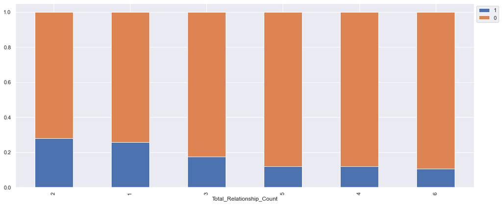

```python
stacked_plot(data['Total_Relationship_Count'])
```

- 1 and 2 have highest attrition. Meaning people who leave are more likely to have less relationship with bank

### Months_Inactive_12_mon vs Attrition_Flag

```
Attrition_Flag             1     0    All
Months_Inactive_12_mon
All                     1627  8500  10127
3                        826  3020   3846
2                        505  2777   3282
4                        130   305    435
1                        100  2133   2233
5                         32   146    178
6                         19   105    124
0                         15    14     29
------------------------------------------------------------------------------------------------------------------------
```

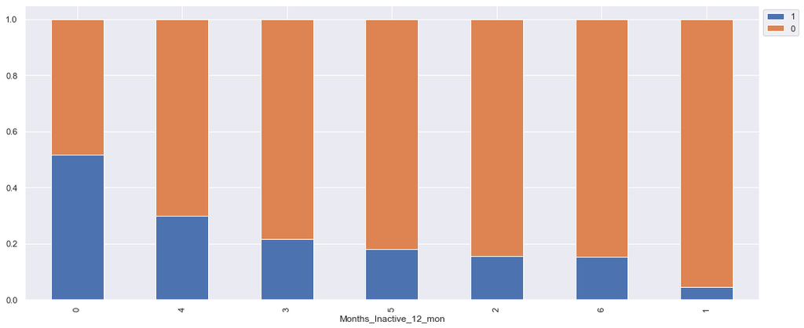

```python
stacked_plot(data['Months_Inactive_12_mon'])
```

- surprisingly 0 months inactive has the highest attrition rate. But the number of records in that group is very less so cant be inferred concretely

### Contacts_Count_12_mon vs Attrition_Flag

```
Attrition_Flag            1     0    All
Contacts_Count_12_mon
All                    1627  8500  10127
3                       681  2699   3380
2                       403  2824   3227
4                       315  1077   1392
1                       108  1391   1499
5                        59   117    176
6                        54     0     54
0                         7   392    399
------------------------------------------------------------------------------------------------------------------------
```

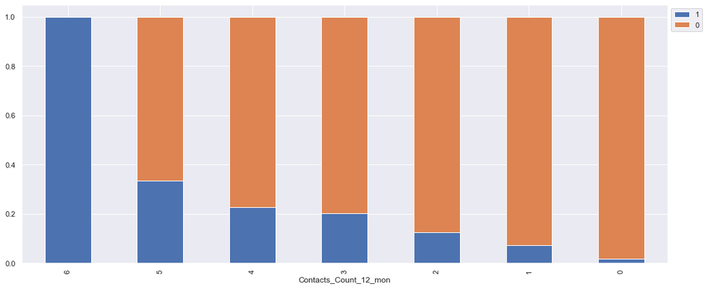

```python
stacked_plot(data['Contacts_Count_12_mon'])
```

- Surprisingly 6 has the highest attrition rate

```python
### Function to plot distributions and Boxplots of enrollees
def plot(x,target='Attrition_Flag'):
    fig,axs = plt.subplots(2,2,figsize=(12,10))
    axs[0, 0].set_title('Distribution of Attrited Customer')
    sns.distplot(data[(data[target] == 1)][x],ax=axs[0,0],color='teal')
    axs[0, 1].set_title('Distribution of Existing Customer')
    sns.distplot(data[(data[target] == 0)][x],ax=axs[0,1],color='orange')
    axs[1,0].set_title('Boxplot w.r.t Attrition_Flag')
    sns.boxplot(data[target],data[x],ax=axs[1,0],palette='gist_rainbow')
    axs[1,1].set_title('Boxplot w.r.t Attrition_Flag - Without outliers')
    sns.boxplot(data[target],data[x],ax=axs[1,1],showfliers=False,palette='gist_rainbow')
    plt.tight_layout()
    plt.show()
```

### Credit_Limit vs Attrition_Flag

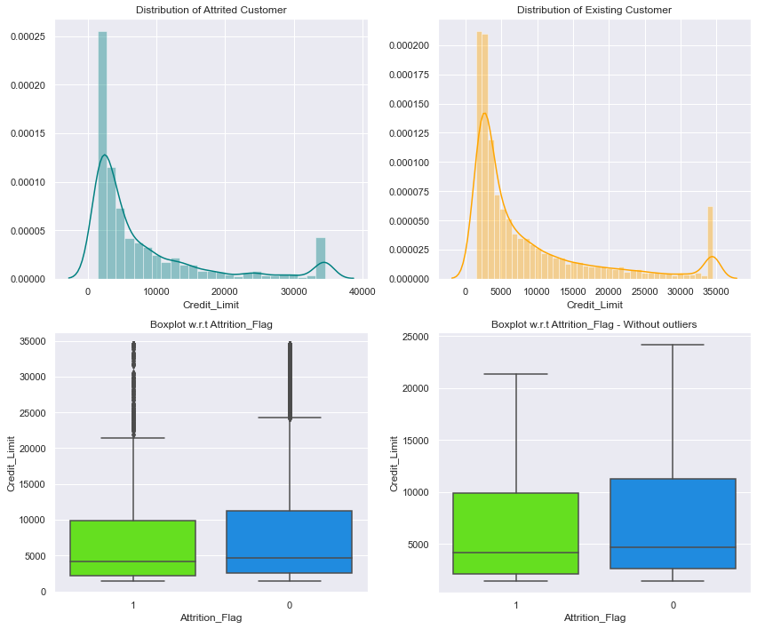

```python
plot('Credit_Limit')
```

- Both Attrited Customer and Existing Customer have similar histogram distribution thats right skewed
- Both Attrited Customer and Existing Customerhave similar box plots showing there isnt much relation

### Total_Revolving_Bal vs Attrition_Flag

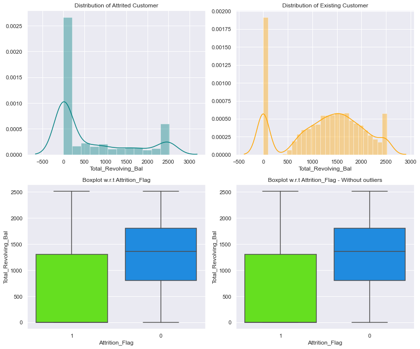

```python
plot('Total_Revolving_Bal')
```

- Existing Customer has a bell curve with 2 peaks in the corners
- Existing Customer has a more higher Total_revolving_bal

### Total_Amt_Chng_Q4_Q1 vs Attrition_Flag

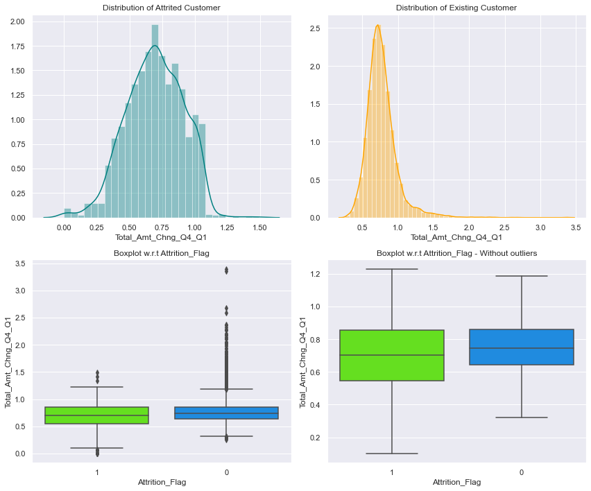

```python
plot('Total_Amt_Chng_Q4_Q1')
```

- Attrited Customer is normally distributed
- Existing customer is skewed to the right
- Box plot is almost similar with Existing customer having more outliers

### Total_Trans_Amt vs Attrition_Flag

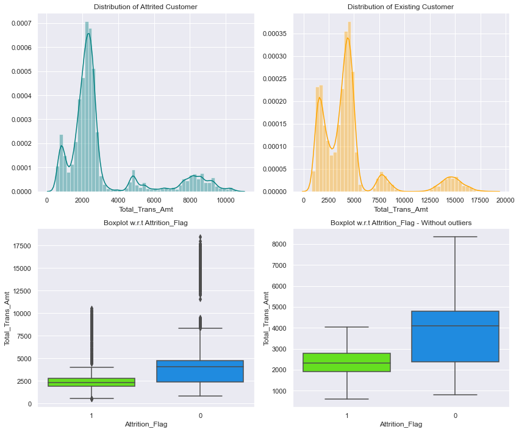

```python
plot('Total_Trans_Amt')
```

- Both types of customers are randomly distributed with a few peaks
- Existing customers seem to have a more Total_trans_amt

### Total_Ct_Chng_Q4_Q1 vs Attrition_Flag

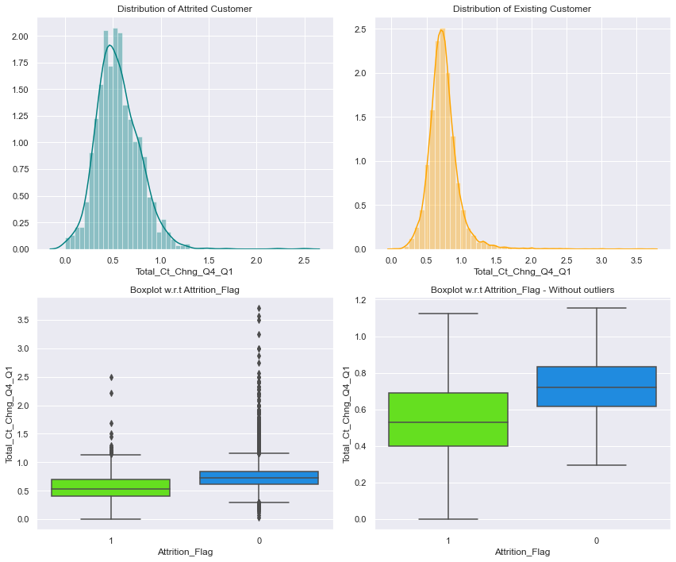

```python
plot('Total_Ct_Chng_Q4_Q1')
```

- Attrited Customer is normally distributed
- Existing customer is skewed to the right
- Existing customer has more outliers and has a higher mean Total_ct_chng_q4_q1

### Avg_Utilization_Ratio vs Attrition_Flag

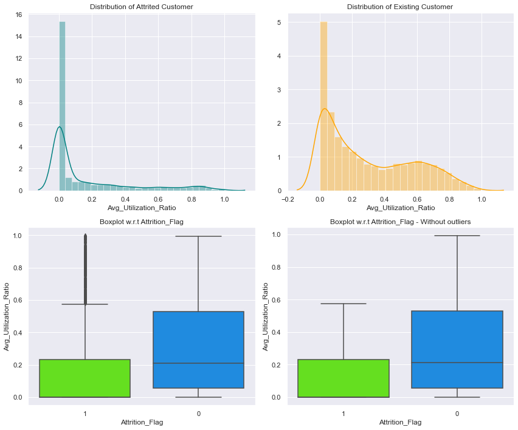

```python
plot('Avg_Utilization_Ratio')
```

- Both types of customers are randomly distributed with a few peaks
- Existing customers seem to have a more Avg_utilization_ratio

# Feature engineering

- Finding value_counts for different categories

```python
cat_cols=['Attrition_Flag','Gender','Education_Level','Marital_Status',
          'Income_Category','Card_Category']
for column in cat_cols:
    print(data[column].value_counts())
    print('-'*30)
```

```
0    8500
1    1627
Name: Attrition_Flag, dtype: int64
------------------------------
F    5358
M    4769
Name: Gender, dtype: int64
------------------------------
Graduate         3128
High School      2013
Unknown          1519
Uneducated       1487
College          1013
Post-Graduate     516
Doctorate         451
Name: Education_Level, dtype: int64
------------------------------
Married     4687
Single      3943
Unknown      749
Divorced     748
Name: Marital_Status, dtype: int64
------------------------------
Less than $40K    3561
$40K - $60K       1790
$80K - $120K      1535
$60K - $80K       1402
Unknown           1112
$120K +            727
Name: Income_Category, dtype: int64
------------------------------
Blue        9436
Silver       555
Gold         116
Platinum      20
Name: Card_Category, dtype: int64
------------------------------
```

- Lets impute the rows with income_category,Education_Level,Marital_Status
- We will use KNN imputer to impute missing values.
- `KNNImputer`: Each sample's missing values are imputed by looking at the n_neighbors nearest neighbors found in the training set. Default value for n_neighbors=5.
- KNN imputer replaces missing values using the average of k nearest non-missing feature values.
- Nearest points are found based on euclidean distance.
- We need to first convert Unknown to NaN

```python
data['Income_Category'].replace('Unknown', np.NaN,inplace=True)
data['Education_Level'].replace('Unknown', np.NaN,inplace=True)
data['Marital_Status'].replace('Unknown', np.NaN,inplace=True)
```

```python
imputer = KNNImputer(n_neighbors=5)
```

```python
reqd_col_for_impute = ['Income_Category','Education_Level','Marital_Status']
```

- we need to pass numerical values for each categorical column for KNN imputation so we will label encode them

```python
data1=data.copy()
```

```python
Income_Category = {'Less than $40K':0,'$40K - $60K':1,'$80K - $120K':2,'$60K - $80K':3,'$120K +':4}
data1['Income_Category'] = data1['Income_Category'].map(Income_Category)

Education_Level = {'Graduate':0,'High School':1,'Uneducated':2,'College':3,'Post-Graduate':4,'Doctorate':5}
data1['Education_Level'] = data1['Education_Level'].map(Education_Level)

Marital_Status = {'Married':0,'Single':1,'Divorced':2}
data1['Marital_Status'] = data1['Marital_Status'].map(Marital_Status)
```

```python
data1.head()
```

|  | Attrition_Flag | Customer_Age | Gender | Dependent_count | Education_Level | Marital_Status | Income_Category | Card_Category | Total_Relationship_Count | Months_Inactive_12_mon | Contacts_Count_12_mon | Credit_Limit | Total_Revolving_Bal | Total_Amt_Chng_Q4_Q1 | Total_Trans_Amt | Total_Ct_Chng_Q4_Q1 | Avg_Utilization_Ratio |
| --- | --- | --- | --- | --- | --- | --- | --- | --- | --- | --- | --- | --- | --- | --- | --- | --- | --- |
| 0 | 0 | 45 | M | 3 | 1 | 0 | 3 | Blue | 5 | 1 | 3 | 12691.0 | 777 | 1.335 | 1144 | 1.625 | 0.061 |
| 1 | 0 | 49 | F | 5 | 0 | 1 | 0 | Blue | 6 | 1 | 2 | 8256.0 | 864 | 1.541 | 1291 | 3.714 | 0.105 |
| 2 | 0 | 51 | M | 3 | 0 | 0 | 2 | Blue | 4 | 1 | 0 | 3418.0 | 0 | 2.594 | 1887 | 2.333 | 0.000 |
| 3 | 0 | 40 | F | 4 | 1 | NaN | 0 | Blue | 3 | 4 | 1 | 3313.0 | 2517 | 1.405 | 1171 | 2.333 | 0.760 |
| 4 | 0 | 40 | M | 3 | 2 | 0 | 3 | Blue | 5 | 1 | 0 | 4716.0 | 0 | 2.175 | 816 | 2.500 | 0.000 |

- Values have been encoded.

### Split Data

```python
X = data1.drop(['Attrition_Flag'],axis=1)
y = data1['Attrition_Flag']
```

```python
# Splitting data into training and test set:
X_train, X_test, y_train, y_test = train_test_split(X, y, test_size=0.3, random_state=7,stratify=y)
print(X_train.shape, X_test.shape)
```

```
(7088, 16) (3039, 16)
```

```python
#Fit and transform the train data
X_train[reqd_col_for_impute]=imputer.fit_transform(X_train[reqd_col_for_impute])

#Transform the test data
X_test[reqd_col_for_impute]=imputer.transform(X_test[reqd_col_for_impute])
```

- checking Unknown is present anywhere in the file

```python
data1[data1.apply(lambda row: row.astype(str).str.contains('Unknown').any(), axis=1)]
```

|  | Attrition_Flag | Customer_Age | Gender | Dependent_count | Education_Level | Marital_Status | Income_Category | Card_Category | Total_Relationship_Count | Months_Inactive_12_mon | Contacts_Count_12_mon | Credit_Limit | Total_Revolving_Bal | Total_Amt_Chng_Q4_Q1 | Total_Trans_Amt | Total_Ct_Chng_Q4_Q1 | Avg_Utilization_Ratio |
| --- | --- | --- | --- | --- | --- | --- | --- | --- | --- | --- | --- | --- | --- | --- | --- | --- | --- |

- All missing values have been treated.
- Let's inverse map the encoded values.

```python
## Function to inverse the encoding
def inverse_mapping(x,y):
    inv_dict = {v: k for k, v in x.items()}
    X_train[y] = np.round(X_train[y]).map(inv_dict).astype('category')
    X_test[y] = np.round(X_test[y]).map(inv_dict).astype('category')
```

```python
inverse_mapping(Income_Category,'Income_Category')
inverse_mapping(Education_Level,'Education_Level')
inverse_mapping(Marital_Status,'Marital_Status')
```

- Checking inverse mapped values/categories.

```python
cols = X_train.select_dtypes(include=['object','category'])
for i in cols.columns:
    print(X_train[i].value_counts())
    print('*'*30)
```

```
F    3753
M    3335
Name: Gender, dtype: int64
Graduate         2440
High School      2054
Uneducated       1184
College           736
Post-Graduate     352
Doctorate         322
Name: Education_Level, dtype: int64
Married     3536
Single      3014
Divorced     538
Name: Marital_Status, dtype: int64
Less than $40K    2481
$40K - $60K       1797
$80K - $120K      1286
$60K - $80K       1020
$120K +            504
Name: Income_Category, dtype: int64
Blue        6619
Silver       373
Gold          81
Platinum      15
Name: Card_Category, dtype: int64
```

```python
cols = X_test.select_dtypes(include=['object','category'])
for i in cols.columns:
    print(X_train[i].value_counts())
    print('*'*30)
```

```
F    3753
M    3335
Name: Gender, dtype: int64
Graduate         2440
High School      2054
Uneducated       1184
College           736
Post-Graduate     352
Doctorate         322
Name: Education_Level, dtype: int64
Married     3536
Single      3014
Divorced     538
Name: Marital_Status, dtype: int64
Less than $40K    2481
$40K - $60K       1797
$80K - $120K      1286
$60K - $80K       1020
$120K +            504
Name: Income_Category, dtype: int64
Blue        6619
Silver       373
Gold          81
Platinum      15
Name: Card_Category, dtype: int64
```

- Inverse mapping returned original labels.

### Encoding categorical varaibles

```python
X_train=pd.get_dummies(X_train,drop_first=True)
X_test=pd.get_dummies(X_test,drop_first=True)
print(X_train.shape, X_test.shape)
```

```
(7088, 26) (3039, 26)
```

## Building the model

### Model evaluation criterion:

#### Model can make wrong predictions as:

1. Predicting a customer will leave credit card services while they will not - False positives or Type 1 error
2. Predicting a customer will not leave credit card services while they will - False negatives or Type 2 error

#### Which case is more important?

- Predicting a customer will leave but in real if they dont leave doesnt cause any loss of revenue to company. However predicting a customer will not leave but in reality if they leave will cause loss of revenue. So Type 2 error should be less.

#### How to reduce this loss i.e need to reduce False Negatives?

- Company would want Recall to be maximized, greater the Recall lesser the chances of false negatives.

```python
##  Function to calculate different metric scores of the model - Accuracy, Recall and Precision
def get_metrics_score(model,train,test,train_y,test_y,flag=True):
    '''
    model : classifier to predict values of X

    '''
    # defining an empty list to store train and test results
    score_list=[]

    pred_train = model.predict(train)
    pred_test = model.predict(test)

    train_acc = model.score(train,train_y)
    test_acc = model.score(test,test_y)

    train_recall = metrics.recall_score(train_y,pred_train)
    test_recall = metrics.recall_score(test_y,pred_test)

    train_precision = metrics.precision_score(train_y,pred_train)
    test_precision = metrics.precision_score(test_y,pred_test)

    score_list.extend((train_acc,test_acc,train_recall,test_recall,train_precision,test_precision))

    # If the flag is set to True then only the following print statements will be dispayed. The default value is set to True.
    if flag == True:
        print("Accuracy on training set : ",model.score(train,train_y))
        print("Accuracy on test set : ",model.score(test,test_y))
        print("Recall on training set : ",metrics.recall_score(train_y,pred_train))
        print("Recall on test set : ",metrics.recall_score(test_y,pred_test))
        print("Precision on training set : ",metrics.precision_score(train_y,pred_train))
        print("Precision on test set : ",metrics.precision_score(test_y,pred_test))

    return score_list # returning the list with train and test scores
```

```python
def make_confusion_matrix(model,y_actual,labels=[1, 0]):
    '''
    model : classifier to predict values of X
    y_actual : ground truth

    '''
    y_predict = model.predict(X_test)
    cm=metrics.confusion_matrix( y_actual, y_predict, labels=[0, 1])
    df_cm = pd.DataFrame(cm, index = [i for i in ["Actual - No","Actual - Yes"]],
                  columns = [i for i in ['Predicted - No','Predicted - Yes']])
    group_counts = ["{0:0.0f}".format(value) for value in
                cm.flatten()]
    group_percentages = ["{0:.2%}".format(value) for value in
                         cm.flatten()/np.sum(cm)]
    labels = [f"{v1}\n{v2}" for v1, v2 in
              zip(group_counts,group_percentages)]
    labels = np.asarray(labels).reshape(2,2)
    plt.figure(figsize = (10,7))
    sns.heatmap(df_cm, annot=labels,fmt='')
    plt.ylabel('True label')
    plt.xlabel('Predicted label')
```

### Logistic Regression

```python
lr = LogisticRegression(random_state=1)
lr.fit(X_train,y_train)
```

```
LogisticRegression(random_state=1)
```

**Let's evaluate the model performance by using KFold and cross_val_score**

- `K-Folds cross-validator` provides dataset indices to split data into train/validation sets. Split dataset into k consecutive stratified folds (without shuffling by default). Each fold is then used once as validation while the k - 1 remaining folds form the training set.

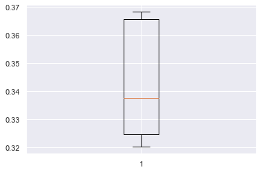

```python
scoring='recall'
kfold=StratifiedKFold(n_splits=5,shuffle=True,random_state=1)     #Setting number of splits equal to 5
cv_result_bfr=cross_val_score(estimator=lr, X=X_train, y=y_train, scoring=scoring, cv=kfold)
#Plotting boxplots for CV scores of model defined above
plt.boxplot(cv_result_bfr)
plt.show()
```

- Performance on training set varies between 0.32 to 0.37 recall.
- Let's check the performance on test data.

```
Accuracy on training set :  0.8775395033860045
Accuracy on test set :  0.8739717012175058
Recall on training set :  0.35118525021949076
Recall on test set :  0.3094262295081967
Precision on training set :  0.7561436672967864
Precision on test set :  0.766497461928934
```

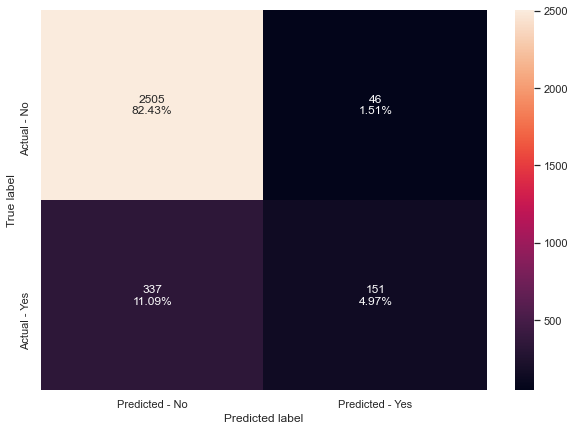

```python
#Calculating different metrics
scores_LR = get_metrics_score(lr,X_train,X_test,y_train,y_test)

# creating confusion matrix
make_confusion_matrix(lr,y_test)
```

- Logistic Regression has given a generalized performance on training and test set.
- Recall is very low, we can try oversampling (increase training data) to see if the model performance can be improved.

### Oversampling train data using SMOTE

```python
from imblearn.over_sampling import SMOTE
```

```python
print("Before UpSampling, counts of label 'Attrited Customer': {}".format(sum(y_train==1)))
print("Before UpSampling, counts of label 'Existing Customer': {} \n".format(sum(y_train==0)))

sm = SMOTE(sampling_strategy = 1 ,k_neighbors = 5, random_state=1)   #Synthetic Minority Over Sampling Technique
X_train_over, y_train_over = sm.fit_resample(X_train, y_train)


print("After UpSampling, counts of label 'Attrited Customer': {}".format(sum(y_train_over==1)))
print("After UpSampling, counts of label 'Existing Customer': {} \n".format(sum(y_train_over==0)))


print('After UpSampling, the shape of train_X: {}'.format(X_train_over.shape))
print('After UpSampling, the shape of train_y: {} \n'.format(y_train_over.shape))
```

```
Before UpSampling, counts of label 'Attrited Customer': 1139
Before UpSampling, counts of label 'Existing Customer': 5949

After UpSampling, counts of label 'Attrited Customer': 5949
After UpSampling, counts of label 'Existing Customer': 5949

After UpSampling, the shape of train_X: (11898, 26)
After UpSampling, the shape of train_y: (11898,)
```

### Logistic Regression on oversampled data

```python
log_reg_over = LogisticRegression(random_state = 1)

# Training the basic logistic regression model with training set
log_reg_over.fit(X_train_over,y_train_over)
```

```
LogisticRegression(random_state=1)
```

**Let's evaluate the model performance by using KFold and cross_val_score**

- `K-Folds cross-validator` provides dataset indices to split data into train/validation sets. Split dataset into k consecutive stratified folds (without shuffling by default). Each fold is then used once as validation while the k - 1 remaining folds form the training set.

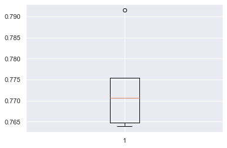

```python
scoring='recall'
kfold=StratifiedKFold(n_splits=5,shuffle=True,random_state=1)     #Setting number of splits equal to 5
cv_result_over=cross_val_score(estimator=log_reg_over, X=X_train_over, y=y_train_over, scoring=scoring, cv=kfold)
#Plotting boxplots for CV scores of model defined above
plt.boxplot(cv_result_over)
plt.show()
```

- Performance of model on training set varies between 0.765 to 0.775 with outlier 0.790, which is an improvement from the previous model
- Let's check the performance on the test set.

```
Accuracy on training set :  0.7803832576903681
Accuracy on test set :  0.7578150707469562
Recall on training set :  0.7759287275172297
Recall on test set :  0.6557377049180327
Precision on training set :  0.7829036635006784
Precision on test set :  0.36036036036036034
```

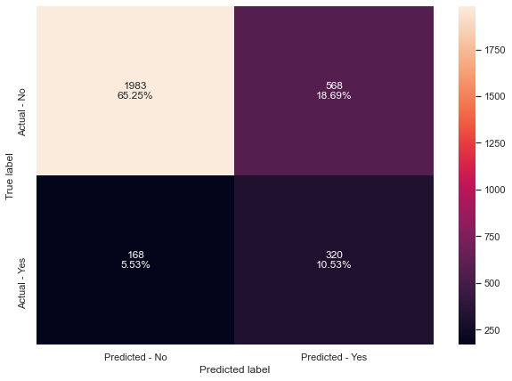

```python
#Calculating different metrics
get_metrics_score(log_reg_over,X_train_over,X_test,y_train_over,y_test)

# creating confusion matrix
make_confusion_matrix(log_reg_over,y_test)
```

- Accuracy on Traning and Test set both has gone down
- Model is not overfitting maybe underfitting.
- Lets try:

  a) Regularization

  b) Undersampling the train to handle the imbalance between classes and check the model performance.

### Regularization

```python
# Choose the type of classifier.
lr_estimator = LogisticRegression(random_state=1,solver='saga')

# Grid of parameters to choose from
parameters = {'C': np.arange(0.1,1.1,0.1)}

# Run the grid search
grid_obj = GridSearchCV(lr_estimator, parameters, scoring='recall')
grid_obj = grid_obj.fit(X_train_over, y_train_over)

# Set the clf to the best combination of parameters
lr_estimator = grid_obj.best_estimator_

# Fit the best algorithm to the data.
lr_estimator.fit(X_train_over, y_train_over)
```

```
LogisticRegression(C=0.1, random_state=1, solver='saga')
```

```
Accuracy on training set :  0.7018826693561944
Accuracy on test set :  0.7913787430075683
Recall on training set :  0.5851403597243234
Recall on test set :  0.5676229508196722
Precision on training set :  0.7633771929824561
Precision on test set :  0.39571428571428574
```

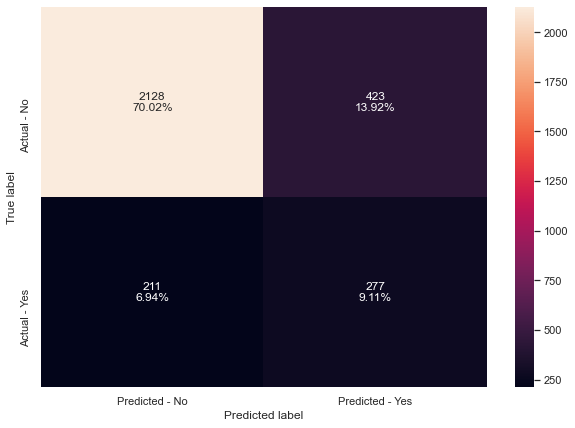

```python
#Calculating different metrics
get_metrics_score(lr_estimator,X_train_over,X_test,y_train_over,y_test)

# creating confusion matrix
make_confusion_matrix(lr_estimator,y_test)
```

- Accuracy on train data has gone down while that of test data has gone up meaning there is less overfitting
- Recall has gone down for both Train and test
- Precision has gone up a bit for test but not enough
- Let's try undersampling now.

```python
from imblearn.under_sampling import RandomUnderSampler
rus = RandomUnderSampler(random_state = 1)
X_train_un, y_train_un = rus.fit_resample(X_train, y_train)
```

```python
print("Before Under Sampling, counts of label 'Attrited Customer': {}".format(sum(y_train==1)))
print("Before Under Sampling, counts of label 'Existing Customer': {} \n".format(sum(y_train==0)))

print("After Under Sampling, counts of label 'Attrited Customer': {}".format(sum(y_train_un==1)))
print("After Under Sampling, counts of label 'Existing Customer': {} \n".format(sum(y_train_un==0)))

print('After Under Sampling, the shape of train_X: {}'.format(X_train_un.shape))
print('After Under Sampling, the shape of train_y: {} \n'.format(y_train_un.shape))
```

```
Before Under Sampling, counts of label 'Attrited Customer': 1139
Before Under Sampling, counts of label 'Existing Customer': 5949

After Under Sampling, counts of label 'Attrited Customer': 1139
After Under Sampling, counts of label 'Existing Customer': 1139

After Under Sampling, the shape of train_X: (2278, 26)
After Under Sampling, the shape of train_y: (2278,)
```

### Logistic Regression on undersampled data

```python
log_reg_under = LogisticRegression(random_state = 1)
log_reg_under.fit(X_train_un,y_train_un )
```

```
LogisticRegression(random_state=1)
```

**Let's evaluate the model performance by using KFold and cross_val_score**

- `K-Folds cross-validator` provides dataset indices to split data into train/validation sets. Split dataset into k consecutive stratified folds (without shuffling by default). Each fold is then used once as validation while the k - 1 remaining folds form the training set.

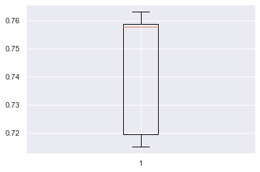

```python
scoring='recall'
kfold=StratifiedKFold(n_splits=5,shuffle=True,random_state=1)     #Setting number of splits equal to 5
cv_result_under=cross_val_score(estimator=log_reg_under, X=X_train_un, y=y_train_un, scoring=scoring, cv=kfold)
#Plotting boxplots for CV scores of model defined above
plt.boxplot(cv_result_under)
plt.show()
```

- Performance of model on training set varies between 0.7 to 0.76, which is an improvement from the initial model(without oversampling)
- Let's check the performance on the test set.

```
Accuracy on training set :  0.7383669885864794
Accuracy on test set :  0.7416913458374466
Recall on training set :  0.742756804214223
Recall on test set :  0.7274590163934426
Precision on training set :  0.7362924281984334
Precision on test set :  0.35253227408143
```

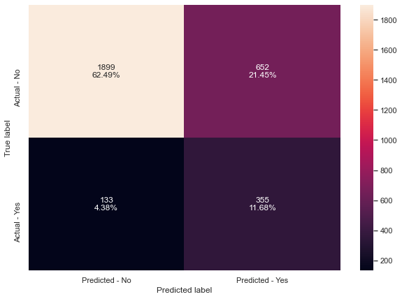

```python
#Calculating different metrics
get_metrics_score(log_reg_under,X_train_un,X_test,y_train_un,y_test)


# creating confusion matrix
make_confusion_matrix(log_reg_under,y_test)
```

- Model has given a generalized performance on training and test set.
- Model performance has not improved much using downsampling
- Recall has improved a lot in both test and train
- Precision has gone down by a lot

## Comparing all the different model performances

```python
# defining list of model
models = [lr]

# defining empty lists to add train and test results
acc_train = []
acc_test = []
recall_train = []
recall_test = []
precision_train = []
precision_test = []

# looping through all the models to get the metrics score - Accuracy, Recall and Precision
for model in models:

    j = get_metrics_score(model,X_train,X_test,y_train,y_test,False)
    acc_train.append(j[0])
    acc_test.append(j[1])
    recall_train.append(j[2])
    recall_test.append(j[3])
    precision_train.append(j[4])
    precision_test.append(j[5])
```

```python
# defining list of models
models = [log_reg_over, lr_estimator]

# looping through all the models to get the metrics score - Accuracy, Recall and Precision
for model in models:

    j = get_metrics_score(model,X_train_over,X_test,y_train_over,y_test,False)
    acc_train.append(j[0])
    acc_test.append(j[1])
    recall_train.append(j[2])
    recall_test.append(j[3])
    precision_train.append(j[4])
    precision_test.append(j[5])
```

```python
# defining list of model
models = [log_reg_under]

# looping through all the models to get the metrics score - Accuracy, Recall and Precision
for model in models:

    j = get_metrics_score(model,X_train_un,X_test,y_train_un,y_test,False)
    acc_train.append(j[0])
    acc_test.append(j[1])
    recall_train.append(j[2])
    recall_test.append(j[3])
    precision_train.append(j[4])
    precision_test.append(j[5])
```

```python
comparison_frame = pd.DataFrame({'Model':['Logistic Regression','Logistic Regression on Oversampled data',
                                          'Logistic Regression-Regularized (Oversampled data)','Logistic Regression on Undersampled data'],
                                          'Train_Accuracy': acc_train,'Test_Accuracy': acc_test,
                                          'Train_Recall':recall_train,'Test_Recall':recall_test,
                                          'Train_Precision':precision_train,'Test_Precision':precision_test})

#Sorting models in decreasing order of test recall
comparison_frame
```

|  | Model | Train_Accuracy | Test_Accuracy | Train_Recall | Test_Recall | Train_Precision | Test_Precision |
| --- | --- | --- | --- | --- | --- | --- | --- |
| 0 | Logistic Regression | 0.877540 | 0.873972 | 0.351185 | 0.309426 | 0.756144 | 0.766497 |
| 1 | Logistic Regression on Oversampled data | 0.780383 | 0.757815 | 0.775929 | 0.655738 | 0.782904 | 0.360360 |
| 2 | Logistic Regression-Regularized (Oversampled d... | 0.701883 | 0.791379 | 0.585140 | 0.567623 | 0.763377 | 0.395714 |
| 3 | Logistic Regression on Undersampled data | 0.738367 | 0.741691 | 0.742757 | 0.727459 | 0.736292 | 0.352532 |

### Summary on the model performances

- Logistic Regression has highest Test accuracy and precision
- Logistic Regression on Undersampled data has highest Test Recall
- Logistic Regression-Regularized (Oversampled data) has 2nd highest accuracy and precision
- All the models score very low on the parformance metrices. looks like logistic regression isnt a good model for this data

### Finding the coefficients

```python
log_odds = log_reg_under.coef_[0]
pd.DataFrame(log_odds, X_train_un.columns, columns=['coef']).T
```

|  | Customer_Age | Dependent_count | Total_Relationship_Count | Months_Inactive_12_mon | Contacts_Count_12_mon | Credit_Limit | Total_Revolving_Bal | Total_Amt_Chng_Q4_Q1 | Total_Trans_Amt | Total_Ct_Chng_Q4_Q1 | ... | Education_Level_Uneducated | Marital_Status_Married | Marital_Status_Single | Income_Category_$40K - $60K | Income_Category_$60K - $80K | Income_Category_$80K - $120K | Income_Category_Less than $40K | Card_Category_Silver | Card_Category_Gold | Card_Category_Platinum |
| --- | --- | --- | --- | --- | --- | --- | --- | --- | --- | --- | --- | --- | --- | --- | --- | --- | --- | --- | --- | --- | --- |
| coef | -0.004302 | 0.156793 | -0.366859 | 0.448197 | 0.589135 | 0.000003 | -0.000711 | -0.036108 | -0.000208 | -0.182965 | ... | 0.000981 | -0.017933 | 0.044403 | -0.00164 | -0.047915 | 0.01576 | 0.074503 | -0.0029 | 0.007092 | 0.004568 |

1 rows × 26 columns

### Converting coefficients to odds

```python
odds = np.exp(np.abs(log_reg_under.coef_[0]))-1
pd.set_option('display.max_rows',None)
pd.DataFrame(odds, X_train_un.columns, columns=['odds']).T
```

|  | Customer_Age | Dependent_count | Total_Relationship_Count | Months_Inactive_12_mon | Contacts_Count_12_mon | Credit_Limit | Total_Revolving_Bal | Total_Amt_Chng_Q4_Q1 | Total_Trans_Amt | Total_Ct_Chng_Q4_Q1 | ... | Education_Level_Uneducated | Marital_Status_Married | Marital_Status_Single | Income_Category_$40K - $60K | Income_Category_$60K - $80K | Income_Category_$80K - $120K | Income_Category_Less than $40K | Card_Category_Silver | Card_Category_Gold | Card_Category_Platinum |
| --- | --- | --- | --- | --- | --- | --- | --- | --- | --- | --- | --- | --- | --- | --- | --- | --- | --- | --- | --- | --- | --- |
| odds | 0.004311 | 0.169753 | 0.443195 | 0.565488 | 0.802429 | 0.000003 | 0.000712 | 0.036768 | 0.000208 | 0.200772 | ... | 0.000982 | 0.018095 | 0.045403 | 0.001641 | 0.049082 | 0.015885 | 0.077349 | 0.002905 | 0.007117 | 0.004579 |

1 rows × 26 columns

# Ensemble models without Grid or Random Search

## Decision Tree Model

```python
from sklearn.tree import DecisionTreeClassifier
from sklearn import tree

#Staring the timer
start_time = timeit.default_timer()

dtree= DecisionTreeClassifier(criterion = 'gini',max_depth=5,random_state=1)
dtree.fit(X_train,y_train)

#stopping the timer and appending to the array to comapre across models
elapsed = timeit.default_timer() - start_time
print(elapsed)
elapsed_arr.append(round(elapsed,3))
```

```
0.0449105999978201
```

```
Accuracy on training set :  0.9228273137697517
Accuracy on test set :  0.9095097071405067
Recall on training set :  0.7032484635645303
Recall on test set :  0.6577868852459017
Precision on training set :  0.7930693069306931
Precision on test set :  0.7482517482517482
```

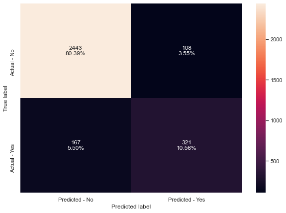

```python
#Calculating different metrics
get_metrics_score(dtree,X_train,X_test,y_train,y_test)


# creating confusion matrix
make_confusion_matrix(dtree,y_test)
```

## Random Forest Model

```python
from sklearn.ensemble import RandomForestClassifier

#Staring the timer
start_time = timeit.default_timer()

rf_estimator=RandomForestClassifier(random_state=1)
rf_estimator.fit(X_train,y_train)

#stopping the timer and appending to the array to comapre across models
elapsed = timeit.default_timer() - start_time
print(elapsed)
elapsed_arr.append(round(elapsed,3))
```

```
0.9391036999986682
```

```
Accuracy on training set :  1.0
Accuracy on test set :  0.9430733794011188
Recall on training set :  1.0
Recall on test set :  0.7028688524590164
Precision on training set :  1.0
Precision on test set :  0.9245283018867925
```

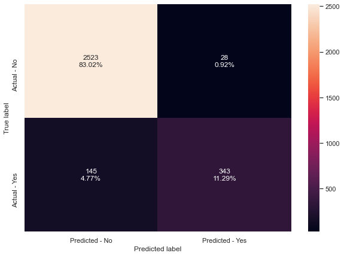

```python
#Calculating different metrics
get_metrics_score(rf_estimator,X_train,X_test,y_train,y_test)


# creating confusion matrix
make_confusion_matrix(rf_estimator,y_test)
```

## Bagging

```python
from sklearn.ensemble import BaggingClassifier

#Staring the timer
start_time = timeit.default_timer()

bagging_estimator=BaggingClassifier(random_state=1)
bagging_estimator.fit(X_train,y_train)

#stopping the timer and appending to the array to comapre across models
elapsed = timeit.default_timer() - start_time
print(elapsed)
elapsed_arr.append(round(elapsed,3))
```

```
0.34269140000105835
```

```
Accuracy on training set :  0.9954853273137697
Accuracy on test set :  0.9470220467258966
Recall on training set :  0.9771729587357331
Recall on test set :  0.7520491803278688
Precision on training set :  0.9946380697050938
Precision on test set :  0.9017199017199017
```

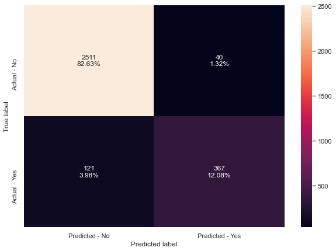

```python
#Calculating different metrics
get_metrics_score(bagging_estimator,X_train,X_test,y_train,y_test)


# creating confusion matrix
make_confusion_matrix(bagging_estimator,y_test)
```

# Boosting

### AdaBoost

```python
from sklearn.ensemble import AdaBoostClassifier, GradientBoostingClassifier

#Staring the timer
start_time = timeit.default_timer()

abc = AdaBoostClassifier(random_state=1)
abc.fit(X_train,y_train)

#stopping the timer and appending to the array to comapre across models
elapsed = timeit.default_timer() - start_time
print(elapsed)
elapsed_arr.append(round(elapsed,3))
```

```
0.3790288000018336
```

```
Accuracy on training set :  0.9422968397291196
Accuracy on test set :  0.9299111549851925
Recall on training set :  0.7787532923617209
Recall on test set :  0.7028688524590164
Precision on training set :  0.8496168582375478
Precision on test set :  0.8345498783454988
```

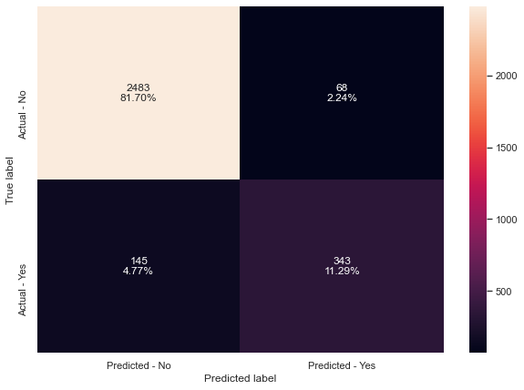

```python
#Calculating different metrics
get_metrics_score(abc,X_train,X_test,y_train,y_test)


# creating confusion matrix
make_confusion_matrix(abc,y_test)
```

### Gradient Boosting Classifier

```python
#Staring the timer
start_time = timeit.default_timer()

gbc = GradientBoostingClassifier(random_state=1)
gbc.fit(X_train,y_train)

#stopping the timer and appending to the array to comapre across models
elapsed = timeit.default_timer() - start_time
print(elapsed)
elapsed_arr.append(round(elapsed,3))
```

```
1.4209262000003946
```

```
Accuracy on training set :  0.9641647855530474
Accuracy on test set :  0.9516288252714709
Recall on training set :  0.8340649692712906
Recall on test set :  0.7663934426229508
Precision on training set :  0.9359605911330049
Precision on test set :  0.918918918918919
```

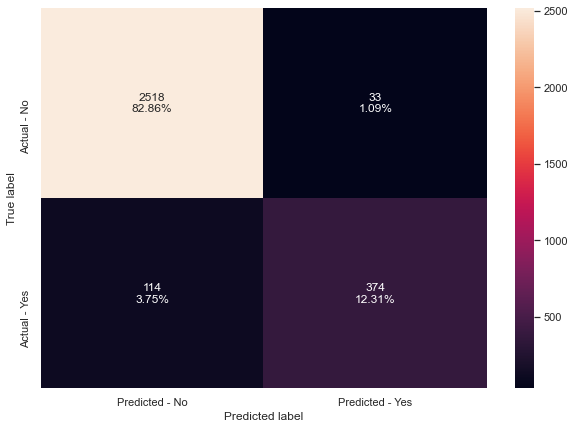

```python
#Calculating different metrics
get_metrics_score(gbc,X_train,X_test,y_train,y_test)


# creating confusion matrix
make_confusion_matrix(gbc,y_test)
```

### XGBoost Classifier

```python
from xgboost import XGBClassifier

#Staring the timer
start_time = timeit.default_timer()

xgb = XGBClassifier(random_state=1)
xgb.fit(X_train,y_train)

#stopping the timer and appending to the array to comapre across models
elapsed = timeit.default_timer() - start_time
print(elapsed)
elapsed_arr.append(round(elapsed,3))
```

```
[15:00:33] WARNING: C:/Users/Administrator/workspace/xgboost-win64_release_1.3.0/src/learner.cc:1061: Starting in XGBoost 1.3.0, the default evaluation metric used with the objective 'binary:logistic' was changed from 'error' to 'logloss'. Explicitly set eval_metric if you'd like to restore the old …
0.5843567000010808
```

```
Accuracy on training set :  1.0
Accuracy on test set :  0.9608423823626193
Recall on training set :  1.0
Recall on test set :  0.8401639344262295
Precision on training set :  1.0
Precision on test set :  0.9090909090909091
```

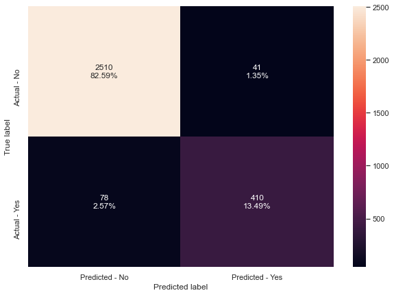

```python
#Calculating different metrics
get_metrics_score(xgb,X_train,X_test,y_train,y_test)


# creating confusion matrix
make_confusion_matrix(xgb,y_test)
```

# Hyperparameter tuning

## Grid Search

### Decision Tree with pipeline and Grid search hyperparameter tuning

```python
from sklearn import decomposition, datasets
from sklearn.pipeline import Pipeline
from sklearn.model_selection import GridSearchCV
from sklearn.preprocessing import StandardScaler

#Staring the timer
start_time = timeit.default_timer()

std_slc = StandardScaler()
pca = decomposition.PCA()
dec_tree = tree.DecisionTreeClassifier()

#Pipeline will helps us by passing modules one by one through GridSearchCV for which we want to get the best parameters.
#So we are making an object pipe to create a pipeline for all the three objects std_scl, pca and dec_tree
pipe = Pipeline(steps=[('std_slc', std_slc),
                           ('pca', pca),
                           ('dec_tree', dec_tree)])
#StandardScaler doesnt need any parameters
#Principal Component Analysis requires a parameter 'n_components' to be optimised
n_components = list(range(1,5))
#DecisionTreeClassifier requires two parameters 'criterion' and 'max_depth' to be optimised
criterion = ['gini', 'entropy']
max_depth = [2,4,6]

parameters = dict(pca__n_components=n_components,
                      dec_tree__criterion=criterion,
                      dec_tree__max_depth=max_depth)

#Making an object for GridSearchCV and fitting the dataset i.e X and y

dtreePipeGSrch = GridSearchCV(pipe, parameters)
dtreePipeGSrch.fit(X_train,y_train)

#stopping the timer and appending to the array to comapre across models
elapsed = timeit.default_timer() - start_time
print(elapsed)
elapsed_arr.append(round(elapsed,3))
```

```
4.673388799998065
```

```
Accuracy on training set :  0.8692155756207675
Accuracy on test set :  0.8624547548535703
Recall on training set :  0.32396839332748023
Recall on test set :  0.27049180327868855
Precision on training set :  0.7015209125475285
Precision on test set :  0.6804123711340206
```

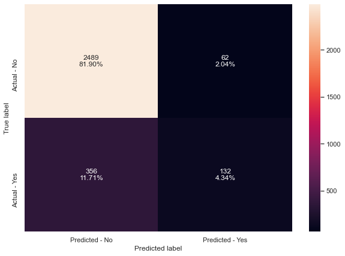

```python
#Calculating different metrics
get_metrics_score(dtreePipeGSrch,X_train,X_test,y_train,y_test)


# creating confusion matrix
make_confusion_matrix(dtreePipeGSrch,y_test)
```

### Random forest with pipeline and Grid search hyperparameter tuning

```python
#Staring the timer
start_time = timeit.default_timer()

std_slc = StandardScaler()
rforest = RandomForestClassifier(random_state=1)

#Pipeline will helps us by passing modules one by one through GridSearchCV for which we want to get the best parameters.
#So we are making an object pipe to create a pipeline for std_scl and rforest
pipe = Pipeline([('scaler', std_slc),('rf', rforest)])
#StandardScaler doesnt need any parameters
#Random Forest classifier parameters to be tuned
n_estimators = [100, 300]
max_depth = [5, 8]
min_samples_split = [2, 5]
min_samples_leaf = [2, 5]

parameters = dict(rf__n_estimators = n_estimators, rf__max_depth = max_depth,
              rf__min_samples_split = min_samples_split,
             rf__min_samples_leaf = min_samples_leaf)

#Making an object for GridSearchCV and fitting the dataset i.e X and y

randomForestPipeGSrch = GridSearchCV(pipe, parameters, cv = 3, verbose = 1, n_jobs = -1)
randomForestPipeGSrch.fit(X_train,y_train)

#stopping the timer and appending to the array to comapre across models
elapsed = timeit.default_timer() - start_time
print(elapsed)
elapsed_arr.append(round(elapsed,3))
```

```
Fitting 3 folds for each of 16 candidates, totalling 48 fits
21.291408900000533
```

```
Accuracy on training set :  0.9444130925507901
Accuracy on test set :  0.9243172096084238
Recall on training set :  0.6883230904302019
Recall on test set :  0.5717213114754098
Precision on training set :  0.9526123936816525
Precision on test set :  0.93
```

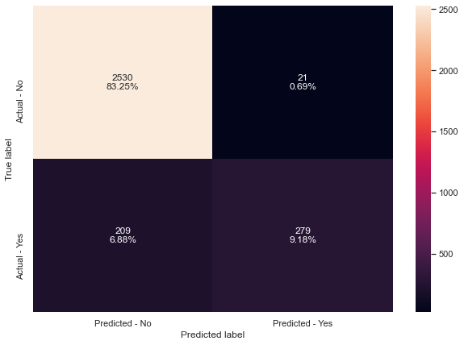

```python
#Calculating different metrics
get_metrics_score(randomForestPipeGSrch,X_train,X_test,y_train,y_test)


# creating confusion matrix
make_confusion_matrix(randomForestPipeGSrch,y_test)
```

### Bagging with pipeline and Grid search hyperparameter tuning

```python
#Staring the timer
start_time = timeit.default_timer()

std_slc = StandardScaler()
bagclf = BaggingClassifier(random_state=1)

#Pipeline will helps us by passing modules one by one through GridSearchCV for which we want to get the best parameters.
#So we are making an object pipe to create a pipeline for std_scl and bagclf
pipe = Pipeline([('scaler', std_slc),('bc', bagclf)])
#StandardScaler doesnt need any parameters
#Bagging classifier parameters to be tuned
n_estimators = [50, 100]
max_features= [0.8, 0.7]
max_samples= [0.8, 0.7]


parameters = dict(bc__n_estimators = n_estimators,bc__max_features=max_features,bc__max_samples=max_samples)

#Making an object for GridSearchCV and fitting the dataset i.e X and y

baggingPipeGSrch = GridSearchCV(pipe, parameters, cv = 3, verbose = 1, n_jobs = -1)
baggingPipeGSrch.fit(X_train,y_train)

#stopping the timer and appending to the array to comapre across models
elapsed = timeit.default_timer() - start_time
print(elapsed)
elapsed_arr.append(round(elapsed,3))
```

```
Fitting 3 folds for each of 8 candidates, totalling 24 fits
12.01641390000077
```

```
Accuracy on training set :  0.9992945823927766
Accuracy on test set :  0.947680157946693
Recall on training set :  0.9956101843722563
Recall on test set :  0.7438524590163934
Precision on training set :  1.0
Precision on test set :  0.9143576826196473
```

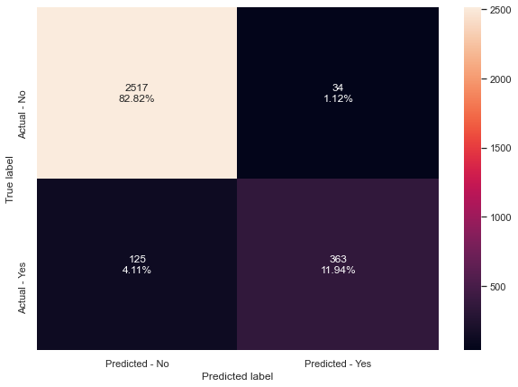

```python
#Calculating different metrics
get_metrics_score(baggingPipeGSrch,X_train,X_test,y_train,y_test)


# creating confusion matrix
make_confusion_matrix(baggingPipeGSrch,y_test)
```

### Adaboost with pipeline and Grid search hyperparameter tuning

```python
#Staring the timer
start_time = timeit.default_timer()

std_slc = StandardScaler()
abclf = AdaBoostClassifier(random_state=0)

#Pipeline will helps us by passing modules one by one through GridSearchCV for which we want to get the best parameters.
#So we are making an object pipe to create a pipeline for std_scl and abcclf
pipe = Pipeline([('scaler', std_slc),('abc', abclf)])
#StandardScaler doesnt need any parameters
#AdaBoost classifier parameters to be tuned
n_estimators = [200, 100]
learning_rate= [0.3, 0.2]

parameters = dict(abc__n_estimators = n_estimators,abc__learning_rate=learning_rate)

#Making an object for GridSearchCV and fitting the dataset i.e X and y

abcPipeGSrch = GridSearchCV(pipe, parameters, cv = 3, verbose = 1, n_jobs = -1)
abcPipeGSrch.fit(X_train,y_train)

#stopping the timer and appending to the array to comapre across models
elapsed = timeit.default_timer() - start_time
print(elapsed)
elapsed_arr.append(round(elapsed,3))
```

```
Fitting 3 folds for each of 4 candidates, totalling 12 fits
5.454348100000061
```

```
Accuracy on training set :  0.9448363431151241
Accuracy on test set :  0.9335307666995722
Recall on training set :  0.7576821773485514
Recall on test set :  0.7049180327868853
Precision on training set :  0.8824130879345603
Precision on test set :  0.8557213930348259
```

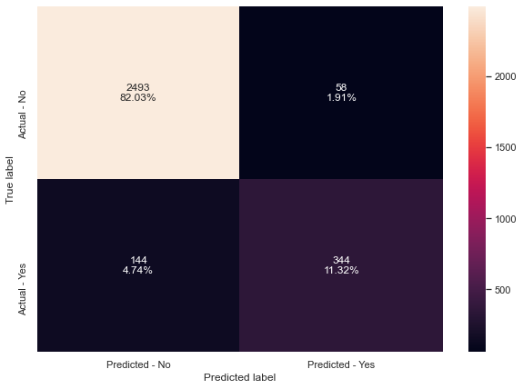

```python
#Calculating different metrics
get_metrics_score(abcPipeGSrch,X_train,X_test,y_train,y_test)


# creating confusion matrix
make_confusion_matrix(abcPipeGSrch,y_test)
```

### Gradientboost with pipeline and Grid search hyperparameter tuning

```python
#Staring the timer
start_time = timeit.default_timer()

std_slc = StandardScaler()
gbclf = GradientBoostingClassifier(random_state=0)

#Pipeline will helps us by passing modules one by one through GridSearchCV for which we want to get the best parameters.
#So we are making an object pipe to create a pipeline for std_scl and gbclf
pipe = Pipeline([('scaler', std_slc),('gbc', gbclf)])
#StandardScaler doesnt need any parameters
#GradientBoost classifier parameters to be tuned
n_estimators = [200, 100]
learning_rate= [0.4, 0.5]

parameters = dict(gbc__n_estimators = n_estimators,gbc__learning_rate=learning_rate)

#Making an object for GridSearchCV and fitting the dataset i.e X and y

gbcPipeGSrch = GridSearchCV(pipe, parameters, cv = 3, verbose = 1, n_jobs = -1)
gbcPipeGSrch.fit(X_train,y_train)

#stopping the timer and appending to the array to comapre across models
elapsed = timeit.default_timer() - start_time
print(elapsed)
elapsed_arr.append(round(elapsed,3))
```

```
Fitting 3 folds for each of 4 candidates, totalling 12 fits
9.239360299998225
```

```
Accuracy on training set :  0.9991534988713319
Accuracy on test set :  0.9582099374794341
Recall on training set :  0.9964881474978051
Recall on test set :  0.8278688524590164
Precision on training set :  0.9982409850483729
Precision on test set :  0.9038031319910514
```

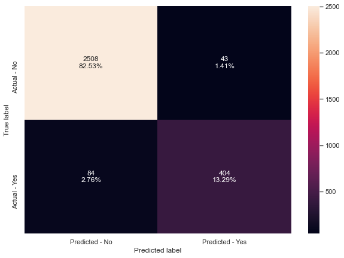

```python
#Calculating different metrics
get_metrics_score(gbcPipeGSrch,X_train,X_test,y_train,y_test)


# creating confusion matrix
make_confusion_matrix(gbcPipeGSrch,y_test)
```

### XGboost with pipeline and Grid search hyperparameter tuning

```python
#Staring the timer
start_time = timeit.default_timer()

std_slc = StandardScaler()
xgbclf = XGBClassifier(random_state=0)

#Pipeline will helps us by passing modules one by one through GridSearchCV for which we want to get the best parameters.
#So we are making an object pipe to create a pipeline for std_scl and xgbclf
pipe = Pipeline([('scaler', std_slc),('xgb', xgbclf)])
#StandardScaler doesnt need any parameters
#XGBoost classifier parameters to be tuned
n_estimators=[50,100]
min_child_weight= [1, 5]
gamma=[0.5, 1]
subsample= [0.6, 0.8]
max_depth= [3, 4]

parameters = dict(xgb__n_estimators = n_estimators,xgb__min_child_weight=min_child_weight,xgb__gamma=gamma,
                  xgb__subsample=subsample,xgb__max_depth=max_depth)

#Making an object for GridSearchCV and fitting the dataset i.e X and y

xgbPipeGSrch = GridSearchCV(pipe, parameters, cv = 3, verbose = 1, n_jobs = -1)
xgbPipeGSrch.fit(X_train,y_train)

#stopping the timer and appending to the array to comapre across models
elapsed = timeit.default_timer() - start_time
print(elapsed)
elapsed_arr.append(round(elapsed,3))
```

```
Fitting 3 folds for each of 32 candidates, totalling 96 fits
[15:01:47] WARNING: C:/Users/Administrator/workspace/xgboost-win64_release_1.3.0/src/learner.cc:1061: Starting in XGBoost 1.3.0, the default evaluation metric used with the objective 'binary:logistic' was changed from 'error' to 'logloss'. Explicitly set eval_metric if you'd like to restore the old …
16.906582600000547
```

```
Accuracy on training set :  0.9943566591422122
Accuracy on test set :  0.9575518262586377
Recall on training set :  0.9789288849868305
Recall on test set :  0.8176229508196722
Precision on training set :  0.9858532272325375
Precision on test set :  0.908883826879271
```

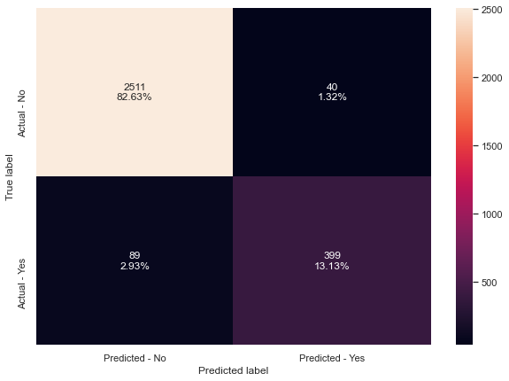

```python
#Calculating different metrics
get_metrics_score(xgbPipeGSrch,X_train,X_test,y_train,y_test)


# creating confusion matrix
make_confusion_matrix(xgbPipeGSrch,y_test)
```

## Random Search

### Decision Tree with pipeline and Randomized search hyperparameter tuning

```python
from sklearn.model_selection import RandomizedSearchCV
from scipy.stats import randint

#Staring the timer
start_time = timeit.default_timer()

std_slc = StandardScaler()
pca = decomposition.PCA()
dec_tree = tree.DecisionTreeClassifier()

#Pipeline will helps us by passing modules one by one through RandomizedSearchCV for which we want to get the best parameters.
#So we are making an object pipe to create a pipeline for all the three objects std_scl, pca and dec_tree
pipe = Pipeline(steps=[('std_slc', std_slc),
                           ('pca', pca),
                           ('dec_tree', dec_tree)])
#StandardScaler doesnt need any parameters
#Principal Component Analysis requires a parameter 'n_components' to be optimised
n_components = list(range(1,5))
#DecisionTreeClassifier requires 4 parameters max_features,min_samples_leaf,criterion and max_depth to be optimised
max_depth= [3, None]
max_features=randint(1, 9)
min_samples_leaf=randint(1, 9)
criterion=["gini", "entropy"]

parameters = { 'dec_tree__max_features': max_features,
               'dec_tree__max_depth': max_depth,
               'dec_tree__min_samples_leaf': min_samples_leaf,
               'dec_tree__criterion':criterion}

#Making an object for GridSearchCV and fitting the dataset i.e X and y

dtreePipeRandSrch = RandomizedSearchCV(pipe, parameters,n_iter = 100, cv = 3, verbose=2, random_state=42, n_jobs = -1)
dtreePipeRandSrch.fit(X_train,y_train)

#stopping the timer and appending to the array to comapre across models
elapsed = timeit.default_timer() - start_time
print(elapsed)
elapsed_arr.append(round(elapsed,3))
```

```
Fitting 3 folds for each of 100 candidates, totalling 300 fits
4.169987699999183
```

```
Accuracy on training set :  0.8669582392776524
Accuracy on test set :  0.8552155314248108
Recall on training set :  0.25021949078138717
Recall on test set :  0.1762295081967213
Precision on training set :  0.7620320855614974
Precision on test set :  0.6935483870967742
```

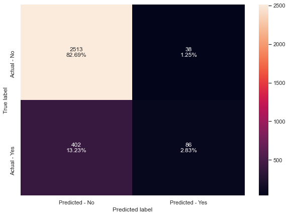

```python
#Calculating different metrics
get_metrics_score(dtreePipeRandSrch,X_train,X_test,y_train,y_test)


# creating confusion matrix
make_confusion_matrix(dtreePipeRandSrch,y_test)
```

### Random Forest with pipeline and Randomized search hyperparameter tuning

```python
#Staring the timer
start_time = timeit.default_timer()

std_slc = StandardScaler()
rforest = RandomForestClassifier(random_state=1)

#Pipeline will helps us by passing modules one by one through RandomizedSearchCV for which we want to get the best parameters.
#So we are making an object pipe to create a pipeline for std_scl and rforest
pipe = Pipeline([('scaler', std_slc),('rf', rforest)])
#StandardScaler doesnt need any parameters
#Random Forest classifier parameters to be tuned
n_estimators = [50,100,200, 300]
max_depth = [1,2,3,5, 8]
min_samples_split = [1,2,3,4,5]
min_samples_leaf = [1,2,3,4, 5]

parameters = dict(rf__n_estimators = n_estimators, rf__max_depth = max_depth,
              rf__min_samples_split = min_samples_split,
             rf__min_samples_leaf = min_samples_leaf)

#Making an object for GridSearchCV and fitting the dataset i.e X and y

randomForestPipeRandSrch = RandomizedSearchCV(pipe, parameters,n_iter = 100, cv = 3, verbose=2, random_state=42, n_jobs = -1)
randomForestPipeRandSrch.fit(X_train,y_train)

#stopping the timer and appending to the array to comapre across models
elapsed = timeit.default_timer() - start_time
print(elapsed)
elapsed_arr.append(round(elapsed,3))
```

```
Fitting 3 folds for each of 100 candidates, totalling 300 fits
49.82447189999948
```

```
Accuracy on training set :  0.9479401805869074
Accuracy on test set :  0.9253043764396183
Recall on training set :  0.7085162423178226
Recall on test set :  0.5799180327868853
Precision on training set :  0.9561611374407583
Precision on test set :  0.9278688524590164
```

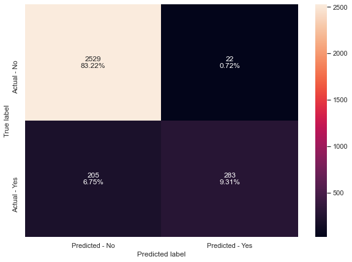

```python
#Calculating different metrics
get_metrics_score(randomForestPipeRandSrch,X_train,X_test,y_train,y_test)


# creating confusion matrix
make_confusion_matrix(randomForestPipeRandSrch,y_test)
```

### Bagging with pipeline and Randomized search hyperparameter tuning

```python
#Staring the timer
start_time = timeit.default_timer()

std_slc = StandardScaler()
bagclf = BaggingClassifier(random_state=1)

#Pipeline will helps us by passing modules one by one through RandomizedSearchCV for which we want to get the best parameters.
#So we are making an object pipe to create a pipeline for std_scl and bagclf
pipe = Pipeline([('scaler', std_slc),('bc', bagclf)])
#StandardScaler doesnt need any parameters
#Bagging classifier parameters to be tuned
n_estimators = [50, 100]
max_features= [0.8, 0.7]
max_samples= [0.8, 0.7]

parameters = dict(bc__n_estimators = n_estimators,bc__max_features=max_features,bc__max_samples=max_samples)

#Making an object for GridSearchCV and fitting the dataset i.e X and y

baggingPipeRandSrch = RandomizedSearchCV(pipe, parameters,n_iter = 100, cv = 3, verbose=2, random_state=42, n_jobs = -1)
baggingPipeRandSrch.fit(X_train,y_train)

#stopping the timer and appending to the array to comapre across models
elapsed = timeit.default_timer() - start_time
print(elapsed)
elapsed_arr.append(round(elapsed,3))
```

```
Fitting 3 folds for each of 8 candidates, totalling 24 fits
12.83337340000071
```

```
Accuracy on training set :  0.9992945823927766
Accuracy on test set :  0.947680157946693
Recall on training set :  0.9956101843722563
Recall on test set :  0.7438524590163934
Precision on training set :  1.0
Precision on test set :  0.9143576826196473
```

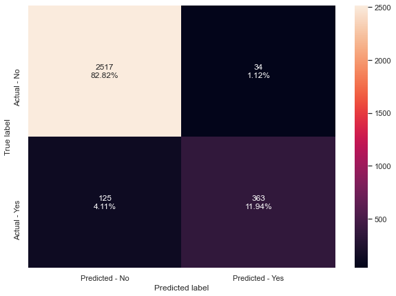

```python
#Calculating different metrics
get_metrics_score(baggingPipeRandSrch,X_train,X_test,y_train,y_test)


# creating confusion matrix
make_confusion_matrix(baggingPipeRandSrch,y_test)
```

### Adaboost with pipeline and Randomized search hyperparameter tuning

```python
#Staring the timer
start_time = timeit.default_timer()

std_slc = StandardScaler()
abclf = AdaBoostClassifier(random_state=0)

#Pipeline will helps us by passing modules one by one through RandomizedSearchCV for which we want to get the best parameters.
#So we are making an object pipe to create a pipeline for std_scl and abclf
pipe = Pipeline([('scaler', std_slc),('abc', abclf)])
#StandardScaler doesnt need any parameters
#AdaBoost classifier parameters to be tuned
n_estimators = [50, 100,150,200]
learning_rate= [0.05, 0.1, 0.2,0.3,0.4,0.5]

parameters = dict(abc__n_estimators = n_estimators,abc__learning_rate=learning_rate)

#Making an object for GridSearchCV and fitting the dataset i.e X and y

abcPipeRandSrch = RandomizedSearchCV(pipe, parameters,n_iter = 100, cv = 3, verbose=2, random_state=42, n_jobs = -1)
abcPipeRandSrch.fit(X_train,y_train)

#stopping the timer and appending to the array to comapre across models
elapsed = timeit.default_timer() - start_time
print(elapsed)
elapsed_arr.append(round(elapsed,3))
```

```
Fitting 3 folds for each of 24 candidates, totalling 72 fits
22.745625099996687
```

```
Accuracy on training set :  0.9468115124153499
Accuracy on test set :  0.9358341559723593
Recall on training set :  0.7787532923617209
Recall on test set :  0.7254098360655737
Precision on training set :  0.8764822134387352
Precision on test set :  0.8530120481927711
```

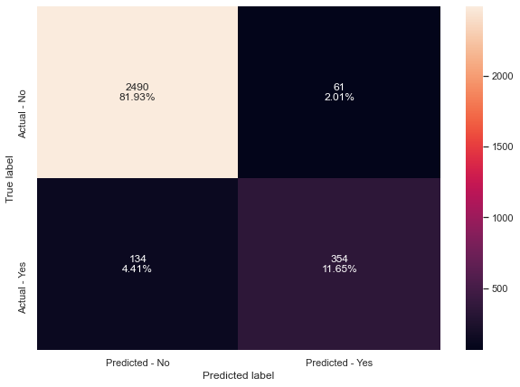

```python
#Calculating different metrics
get_metrics_score(abcPipeRandSrch,X_train,X_test,y_train,y_test)


# creating confusion matrix
make_confusion_matrix(abcPipeRandSrch,y_test)
```

### Gradientboost with pipeline and Randomized search hyperparameter tuning

```python
#Staring the timer
start_time = timeit.default_timer()

std_slc = StandardScaler()
gbclf = GradientBoostingClassifier(random_state=0)

#Pipeline will helps us by passing modules one by one through RandomizedSearchCV for which we want to get the best parameters.
#So we are making an object pipe to create a pipeline for std_scl and gbclf
pipe = Pipeline([('scaler', std_slc),('gbc', gbclf)])
#StandardScaler doesnt need any parameters
#GradientBoost classifier parameters to be tuned
n_estimators = [50, 100,150,200]
learning_rate= [0.05, 0.1, 0.2,0.3,0.4,0.5]

parameters = dict(gbc__n_estimators = n_estimators,gbc__learning_rate=learning_rate)

#Making an object clf_GS for GridSearchCV and fitting the dataset i.e X and y

gbcPipeRandSrch = RandomizedSearchCV(pipe, parameters, cv = 3, verbose = 1, n_jobs = -1)
gbcPipeRandSrch.fit(X_train,y_train)

#stopping the timer and appending to the array to comapre across models
elapsed = timeit.default_timer() - start_time
print(elapsed)
elapsed_arr.append(round(elapsed,3))
```

```
Fitting 3 folds for each of 10 candidates, totalling 30 fits
11.352483099999517
```

```
Accuracy on training set :  0.9864559819413092
Accuracy on test set :  0.9591971043106285
Recall on training set :  0.9446883230904302
Recall on test set :  0.8094262295081968
Precision on training set :  0.9702434625788999
Precision on test set :  0.9272300469483568
```

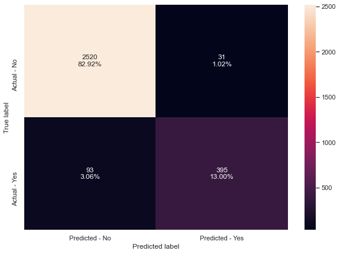

```python
#Calculating different metrics
get_metrics_score(gbcPipeRandSrch,X_train,X_test,y_train,y_test)


# creating confusion matrix
make_confusion_matrix(gbcPipeRandSrch,y_test)
```

### XGboost with pipeline and Randomized search hyperparameter tuning

```python
start_time = timeit.default_timer()

std_slc = StandardScaler()
xgbclf = XGBClassifier(random_state=0)

#Pipeline will helps us by passing modules one by one through RandomizedSearchCV for which we want to get the best parameters.
#So we are making an object pipe to create a pipeline for std_scl and xgbclf
pipe = Pipeline([('scaler', std_slc),('xgb', xgbclf)])
#StandardScaler doesnt need any parameters
#XGBoost classifier parameters to be tuned
n_estimators=[50,100,150,200]
min_child_weight= [1,2,3,4, 5]
gamma=[0.5,0.7,0.9, 1]
subsample= [0.6, 0.8,0.9]
max_depth= [1,2,3, 4]

parameters = dict(xgb__n_estimators = n_estimators,xgb__min_child_weight=min_child_weight,xgb__gamma=gamma,
                  xgb__subsample=subsample,xgb__max_depth=max_depth)

#Making an object clf_GS for GridSearchCV and fitting the dataset i.e X and y

xgbPipeRandSrch = RandomizedSearchCV(pipe, parameters, cv = 3, verbose = 1, n_jobs = -1)
xgbPipeRandSrch.fit(X_train,y_train)

elapsed = timeit.default_timer() - start_time
print(elapsed)
elapsed_arr.append(round(elapsed,3))
```

```
Fitting 3 folds for each of 10 candidates, totalling 30 fits
[15:03:40] WARNING: C:/Users/Administrator/workspace/xgboost-win64_release_1.3.0/src/learner.cc:1061: Starting in XGBoost 1.3.0, the default evaluation metric used with the objective 'binary:logistic' was changed from 'error' to 'logloss'. Explicitly set eval_metric if you'd like to restore the old …
8.011741800000891
```

```
Accuracy on training set :  0.9984480812641083
Accuracy on test set :  0.9601842711418229
Recall on training set :  0.9947322212467077
Recall on test set :  0.8319672131147541
Precision on training set :  0.9956063268892794
Precision on test set :  0.9123595505617977
```

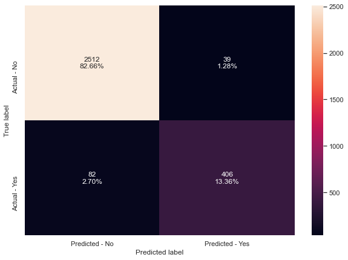

```python
#Calculating different metrics
get_metrics_score(xgbPipeRandSrch,X_train,X_test,y_train,y_test)


# creating confusion matrix
make_confusion_matrix(xgbPipeRandSrch,y_test)
```